# Data Processing in R

August 11, 2016

## Repo

All slides and code examples can be found on my GitHub:

https://github.com/BruceBugbee/rmacc-R-talk

## What is R?

R is an open source statistical programming language designed to be good at things involving data.

[figure not shown]

http://spectrum.ieee.org/computing/software/the-2016-top-programming-languages

## What is a Data Analysis Pipeline?

### You worked hard and got all of this data. Now what?

Good data analysis frameworks have lots of pieces:

- Importing data
- Getting data into a usable form
- Cleaning data
- Slicing, subsetting, merging, etc.
- Visualization
- Exploratory analysis
- Complicated statistical models

## Data storage structures in R

R is an object oriented programming language and has the corresponding capabilities for creating various data structures. However, the bulk of common tasks are done using the base data storage objects:

- Vectors
- Matrices/Arrays
- Data frames, tables, etc. (tabular data of varying types)
- Lists
- Factors

## Getting data into R

**Tabular Data**

- CSV, tab delimited, JSON, etc.
- base functions (read.table), **readr** (efficient versions), **jsonlite** (JSON interpretation)

**Databases**

- **dplyr**, **RSQLite**, **RMySQL**, etc.

**API/Web**

- **httr** (API access)
- **RCurl** (libcurl wrapper)
- rOpenSci (list of open science data packages)

## Data Analysis Pipeline Goals

Once data get’s brought into R, it can be easy to lose track of things. A good data analysis pipeline should be:

- Efficient
- Readable
- Interpretable
- Reproducible
- Flexible

## My Pipeline

**dplyr**

- Solid frame work for slicing, filtering, grouping, and combining data frames
- Easy integration with database backends
- Provides %>% piping operated (integrated from **magrittr**)
- Functions written in C++ to leverage speed ups

**tidyr**

- Functionality for reshaping data frames
- “Tidy data” –> each row an observation, each column a variable (Long vs wide)

## Let’s set up our workflow

```r
library(dplyr)
library(tidyr)
```

## Going to need some data to play with

```r
library(nycflights13)
head(flights) #on-time data for departure flights in NYC for 2013
```

```
## # A tibble: 6 x 19
##    year month   day dep_time sched_dep_time dep_delay arr_time sched_arr_time
##   <int> <int> <int>    <int>          <int>     <dbl>    <int>          <int>
## 1  2013     1     1      517            515         2      830            819
## 2  2013     1     1      533            529         4      850            830
## 3  2013     1     1      542            540         2      923            850
## 4  2013     1     1      544            545        -1     1004           1022
## 5  2013     1     1      554            600        -6      812            837
## 6  2013     1     1      554            558        -4      740            728
## # … with 11 more variables: arr_delay <dbl>, carrier <chr>, flight <int>,
## #   tailnum <chr>, origin <chr>, dest <chr>, air_time <dbl>, distance <dbl>,
## #   hour <dbl>, minute <dbl>, time_hour <dttm>
```

## Common tasks

Most data analysis problems involve a handful of common tasks:

- Subsetting
- Mutating
- Grouping
- Summarizing
- Combining
- Reshaping

Even the most involved tasks typically are just combinations of these simple operations.

## Subsetting

### Subsetting Columns

The *select* function is the workhorse for select sets of columns from a data frame.

```r
flights_small <- select(flights, carrier, flight, origin)
#Notice the lack of "" around column names
#vignette("nse") has a lot of info on non standard evaluation
glimpse(flights_small, width = 50)
```

```
## Rows: 336,776
## Columns: 3
## $ carrier <chr> "UA", "UA", "AA", "B6", "DL", "…
## $ flight  <int> 1545, 1714, 1141, 725, 461, 169…
## $ origin  <chr> "EWR", "LGA", "JFK", "JFK", "LG…
```

## Subsetting

### Special Functions for Select

**select** has a number of special functions that makes dealing with large sets of columns easy.

```r
select(flights, contains("time")) #matches character string
select(flights, starts_with("air"))
select(flights, ends_with("num"))
select(flights, matches("ta.")) #regular expression matches
select(flights, one_of(c("tailnum", "distance")))
select(flights, num_range("x", 1:2)) #any column of the form x1, x2
```

## Subsetting

### Removing Columns

Just like with base R, removal can be done by using a ‘-’ with the appropriate index. These work in select as well.

```r
flights_noyear <- select(flights, -year)
flights_notimeordelay <- select(flights, -contains("time"),
                                -contains("delay"))
```

## Subsetting

### Removing Columns

```r
glimpse(flights_notimeordelay, width = 50)
```

```
## Rows: 336,776
## Columns: 11
## $ year     <int> 2013, 2013, 2013, 2013, 2013, …
## $ month    <int> 1, 1, 1, 1, 1, 1, 1, 1, 1, 1, …
## $ day      <int> 1, 1, 1, 1, 1, 1, 1, 1, 1, 1, …
## $ carrier  <chr> "UA", "UA", "AA", "B6", "DL", …
## $ flight   <int> 1545, 1714, 1141, 725, 461, 16…
## $ tailnum  <chr> "N14228", "N24211", "N619AA", …
## $ origin   <chr> "EWR", "LGA", "JFK", "JFK", "L…
## $ dest     <chr> "IAH", "IAH", "MIA", "BQN", "A…
## $ distance <dbl> 1400, 1416, 1089, 1576, 762, 7…
## $ hour     <dbl> 5, 5, 5, 5, 6, 5, 6, 6, 6, 6, …
## $ minute   <dbl> 15, 29, 40, 45, 0, 58, 0, 0, 0…
```

## Subsetting

### Subsetting Rows

The **filter** function is pretty robust at pulling out subsets of data that meet some logical condition.

```r
flights_united <- filter(flights, carrier == "UA")
flights_morningdep <- filter(flights, dep_time <= 1200)
flights_special <- filter(flights, dest == "DEN" &
                            carrier == "DL" &
                            between(dep_time, 1000, 1400) &
                            month %in% c(6, 7, 8))
```

## Subsetting

### Removing Duplicate Rows

The **distinct** function can be useful for dealing with duplicate entries.

```r
flights_distinct <- distinct(flights)
nrow(flights_distinct) == nrow(flights) #check dimensions
```

```
## [1] TRUE
```

## Subsetting

### Subsetting Rows

```r
flights_special
```

```
## # A tibble: 1 x 19
##    year month   day dep_time sched_dep_time dep_delay arr_time sched_arr_time
##   <int> <int> <int>    <int>          <int>     <dbl>    <int>          <int>
## 1  2013     7     5     1009           1015        -6     1156           1239
## # … with 11 more variables: arr_delay <dbl>, carrier <chr>, flight <int>,
## #   tailnum <chr>, origin <chr>, dest <chr>, air_time <dbl>, distance <dbl>,
## #   hour <dbl>, minute <dbl>, time_hour <dttm>
```

## Subsetting

### Sampling Data Frames

**sample_n** will sample a given number of rows while **sample_frac** will sample a given proportion

```r
sample_n(flights, 100)
sample_frac(flights, 0.1)
```

## Subsetting

### Slicing Data Frames

**slice** can be used to pull out specific rows while **top_n** can be used to pull top/bottom sets

```r
slice(flights, 1:n()) #note that n() is a special function in dplyr
slice(flights, 10:n())
top_n(flights, 100) #first 100 entries
top_n(flights, -50) #bottom 50
```

Note that you can also use the **filter** function to deal with this stuff by calling the special **row_number** function but will be slower.

## Mutating

### Creating New Columns

**mutate** is the workhorse for calculating new variables. The output of the function being called by **mutate** can have one of two results: - output of the same length as the number of rows in the data frame - scalar output (will map single value to every entry)

```r
mutate(flights, distance = distance * 1.6) #convert to km
mutate(flights, carrier_flight = paste(carrier, flight))
mutate(flights, max_delay = max(c(dep_delay, arr_delay))) #scalar
```

Operations are carried out across columns very similar to the vectorized forms of R’s base operations. **mutate** is useful for adding new columns or modifying existing

## Mutating

### Mutating Multiple Columns

```r
mutate(flights, carrier_flight = paste(carrier, flight),
       distance_km = distance * 1.6)
```

## Mutating

### Special Mutate Functions

```r
flights_small <- select(flights, month, day, distance)
get_months <- function(x) return(month.abb[x])
flights_special <- mutate_at(flights_small, vars(month), get_months)
head(flights_special)
```

```
## # A tibble: 6 x 3
##   month   day distance
##   <chr> <int>    <dbl>
## 1 Jan       1     1400
## 2 Jan       1     1416
## 3 Jan       1     1089
## 4 Jan       1     1576
## 5 Jan       1      762
## 6 Jan       1      719
```

## Mutating

### Special Mutate Functions

```r
flights_special2 <- mutate_if(flights_special, is.character, toupper)
head(flights_special2)
```

```
## # A tibble: 6 x 3
##   month   day distance
##   <chr> <int>    <dbl>
## 1 JAN       1     1400
## 2 JAN       1     1416
## 3 JAN       1     1089
## 4 JAN       1     1576
## 5 JAN       1      762
## 6 JAN       1      719
```

## Mutating

### Keeping Only New Columns

**transmute** does the same thing as **mutate** except it drops all of the old columns as well.

```r
flights_km <- transmute(flights, distance_km = distance * 1.6)
head(flights_km)
```

```
## # A tibble: 6 x 1
##   distance_km
##         <dbl>
## 1       2240
## 2       2266.
## 3       1742.
## 4       2522.
## 5       1219.
## 6       1150.
```

## Grouping

Looking at the entire data set is interesting, but often time comparisons want to be made across multiple groups. **group_by** provides this functionality

```r
flights_by_month <- group_by(flights, month)
class(flights)
```

```
## [1] "tbl_df"     "tbl"        "data.frame"
```

```r
class(flights_by_month)
```

```
## [1] "grouped_df" "tbl_df"     "tbl"        "data.frame"
```

## Grouping

```r
print(flights_by_month, width = 60)
```

```
## # A tibble: 336,776 x 19
## # Groups:   month [12]
##     year month   day dep_time sched_dep_time dep_delay
##    <int> <int> <int>    <int>          <int>     <dbl>
##  1  2013     1     1      517            515         2
##  2  2013     1     1      533            529         4
##  3  2013     1     1      542            540         2
##  4  2013     1     1      544            545        -1
##  5  2013     1     1      554            600        -6
##  6  2013     1     1      554            558        -4
##  7  2013     1     1      555            600        -5
##  8  2013     1     1      557            600        -3
##  9  2013     1     1      557            600        -3
## 10  2013     1     1      558            600        -2
## # … with 336,766 more rows, and 13 more variables:
## #   arr_time <int>, sched_arr_time <int>, arr_delay <dbl>,
## #   carrier <chr>, flight <int>, tailnum <chr>,
## #   origin <chr>, dest <chr>, air_time <dbl>,
## #   distance <dbl>, hour <dbl>, minute <dbl>,
## #   time_hour <dttm>
```

## Grouping

### How Grouping Works

The **grouped_df** structures can be thought of as many smaller data frames kept together. Instead of operations being done over the entire data frame, they are done over each sub data frame.

```r
flights_max <- mutate(flights, max_day = max(day))
flights_max2 <- mutate(flights_by_month, max_day = max(day))
```

## Grouping

### How Grouping Works

```r
table(flights_max$max_day)
```

```
##
##     31
## 336776
```

```r
table(flights_max2$max_day)
```

```
##
##     28     30     31
##  24951 111415 200410
```

## Grouping

### Ungrouping

The **ungroup** function removes the grouping structure of a data frame.

```r
flights2 <- ungroup(flights_by_month)
class(flights2)
```

```
## [1] "tbl_df"     "tbl"        "data.frame"
```

## Summarising

### Where Groups Are Powerful

The **summarise** function produces scalar summary statistics according to the grouping structure present. For ungrouped data, it defaults to the entire data frame.

```r
summarise(flights, Delay_Avg = mean(arr_delay, na.rm = T),
          Distance_Avg = mean(distance),
          Distance_SD = sd(distance),
          Most_Common_Carrier = names(sort(table(carrier)))[1])
```

```
## # A tibble: 1 x 4
##   Delay_Avg Distance_Avg Distance_SD Most_Common_Carrier
##       <dbl>        <dbl>       <dbl> <chr>
## 1      6.90        1040.        733. OO
```

## Summarising

### Where Groups Are Powerful

```r
summarise(flights_by_month, Delay_Avg = mean(arr_delay, na.rm = T),
          Distance_Avg = mean(distance),
          Distance_SD = sd(distance),
          Most_Common_Carrier = names(sort(table(carrier)))[1])
```

## Summarising

### Where Groups Are Powerful

```
## # A tibble: 12 x 5
##    month Delay_Avg Distance_Avg Distance_SD Most_Common_Carrier
##    <int>     <dbl>        <dbl>       <dbl> <chr>
##  1     1     6.13         1007.        719. OO
##  2     2     5.61         1001.        711. HA
##  3     3     5.81         1012.        705. YV
##  4     4    11.2          1039.        725. HA
##  5     5     3.52         1041.        742. HA
##  6     6    16.5          1057.        749. OO
##  7     7    16.7          1059.        748. HA
##  8     8     6.04         1062.        751. OO
##  9     9    -4.02         1041.        746. OO
## 10    10    -0.167        1039.        735. HA
## 11    11     0.461        1050.        731. OO
## 12    12    14.9          1065.        727. HA
```

## Summarising

### Where Groups Are Powerful

```r
flights_by_carrier  <- group_by(flights, carrier)
summarise(flights_by_carrier, Delay_Avg = mean(arr_delay, na.rm = T))
```

## Summarising

### Where Groups Are Powerful

```
## # A tibble: 16 x 2
##    carrier Delay_Avg
##    <chr>       <dbl>
##  1 9E          7.38
##  2 AA          0.364
##  3 AS         -9.93
##  4 B6          9.46
##  5 DL          1.64
##  6 EV         15.8
##  7 F9         21.9
##  8 FL         20.1
##  9 HA         -6.92
## 10 MQ         10.8
## 11 OO         11.9
## 12 UA          3.56
## 13 US          2.13
## 14 VX          1.76
## 15 WN          9.65
## 16 YV         15.6
```

## Summarising

### Multiple Groups

You can nest groups by specifying multiple grouping columns in **group_by**.

```r
flights_by_date <- group_by(flights, month, day)
```

## Summarising

### Multiple Groups

```
## # A tibble: 336,776 x 19
## # Groups:   month, day [365]
##     year month   day dep_time sched_dep_time dep_delay arr_time sched_arr_time
##    <int> <int> <int>    <int>          <int>     <dbl>    <int>          <int>
##  1  2013     1     1      517            515         2      830            819
##  2  2013     1     1      533            529         4      850            830
##  3  2013     1     1      542            540         2      923            850
##  4  2013     1     1      544            545        -1     1004           1022
##  5  2013     1     1      554            600        -6      812            837
##  6  2013     1     1      554            558        -4      740            728
##  7  2013     1     1      555            600        -5      913            854
##  8  2013     1     1      557            600        -3      709            723
##  9  2013     1     1      557            600        -3      838            846
## 10  2013     1     1      558            600        -2      753            745
## # … with 336,766 more rows, and 11 more variables: arr_delay <dbl>,
## #   carrier <chr>, flight <int>, tailnum <chr>, origin <chr>, dest <chr>,
## #   air_time <dbl>, distance <dbl>, hour <dbl>, minute <dbl>, time_hour <dttm>
```

## Summarising

### Multiple Groups

```r
summarise(flights_by_date, Delay_Avg = mean(arr_delay, na.rm = T),
          Distance_Avg = mean(distance),
          Distance_SD = sd(distance),
          Most_Common_Carrier = names(sort(table(carrier)))[1])
```

## Summarising

### Multiple Groups

```
## # A tibble: 365 x 6
## # Groups:   month [12]
##    month   day Delay_Avg Distance_Avg Distance_SD Most_Common_Carrier
##    <int> <int>     <dbl>        <dbl>       <dbl> <chr>
##  1     1     1    12.7          1077.        728. HA
##  2     1     2    12.7          1053.        722. HA
##  3     1     3     5.73         1037.        715. HA
##  4     1     4    -1.93         1032.        716. HA
##  5     1     5    -1.53         1068.        741. HA
##  6     1     6     4.24         1052.        728. HA
##  7     1     7    -4.95          998.        719. HA
##  8     1     8    -3.23          986.        714. HA
##  9     1     9    -0.264         981.        707. HA
## 10     1    10    -5.90          993.        718. HA
## # … with 355 more rows
```

## Combining

### Joins

**dplyr** has multiple types of join operators for combining multiple data frames by common factors.

- **inner_join**: all rows of **x** that have matches in **y**
- **left_join**: non matching rows of **x** are giving NA values for columns in **y**
- **right_join**: all rows of **y** that have matches in **x** with NAs for columns of **x**
- **semi_join**: all rows of **x** that have matches in **y**, keeps only colmuns from **x**
- **full_join**: puts NAs where there are non matches

## Combining

### Binds

Bind operators simply append data frames together with some attempts at column matching (**bind_rows**) if available.

- **bind_rows**: akin to **rbind** in base R
- **bind_cols**: akin to **cbind** in base R

Note: **bind_rows** and **bind_cols** can be used over lists of data frames. This is particularly useful when you are pulling output out of a loop.

## Combining

```r
airlines
```

```
## # A tibble: 16 x 2
##    carrier name
##    <chr>   <chr>
##  1 9E      Endeavor Air Inc.
##  2 AA      American Airlines Inc.
##  3 AS      Alaska Airlines Inc.
##  4 B6      JetBlue Airways
##  5 DL      Delta Air Lines Inc.
##  6 EV      ExpressJet Airlines Inc.
##  7 F9      Frontier Airlines Inc.
##  8 FL      AirTran Airways Corporation
##  9 HA      Hawaiian Airlines Inc.
## 10 MQ      Envoy Air
## 11 OO      SkyWest Airlines Inc.
## 12 UA      United Air Lines Inc.
## 13 US      US Airways Inc.
## 14 VX      Virgin America
## 15 WN      Southwest Airlines Co.
## 16 YV      Mesa Airlines Inc.
```

## Combining

```r
flights_with_airlines <- left_join(flights, airlines, by = "carrier")
select(flights_with_airlines, carrier, name)
```

```
## # A tibble: 336,776 x 2
##    carrier name
##    <chr>   <chr>
##  1 UA      United Air Lines Inc.
##  2 UA      United Air Lines Inc.
##  3 AA      American Airlines Inc.
##  4 B6      JetBlue Airways
##  5 DL      Delta Air Lines Inc.
##  6 UA      United Air Lines Inc.
##  7 B6      JetBlue Airways
##  8 EV      ExpressJet Airlines Inc.
##  9 B6      JetBlue Airways
## 10 AA      American Airlines Inc.
## # … with 336,766 more rows
```

## Piping

### Motivating example

```r
flights2 <- group_by(filter(left_join(flights, airlines,
                                      by = "carrier") ,
                            carrier %in% c("WN", "UA", "VX", "DL")),
                     name)
```

## Piping

### Motivating example

Slightly more readable code:

```r
flights2 <- left_join(flights, airlines, by = "carrier")
flights3 <- filter(flights2, carrier %in% c("WN", "UA", "VX", "DL"))
flights4 <- group_by(flights3, name)
flights_sum <- summarise(flights4,
                         Avg_Distance = mean(distance, na.rm = T),
                         Avg_Delay = mean(arr_delay, na.rm = T))
```

## Piping

### Motivating example

```r
flights_sum
```

```
## # A tibble: 4 x 3
##   name                   Avg_Distance Avg_Delay
##   <chr>                         <dbl>     <dbl>
## 1 Delta Air Lines Inc.          1237.      1.64
## 2 Southwest Airlines Co.         996.      9.65
## 3 United Air Lines Inc.         1529.      3.56
## 4 Virgin America                2499.      1.76
```

## Piping

### Messy code

This solution works ok and yields valid results. However, it is really easy to loose track of all these different data frame floating around. This leads to messy and potentially troublesome code. It is quite easy to make mistakes or lose track of goals when dealing with many nested function calls.

This is where the **%>%** piping operator comes into play! This operator takes the data frame on the left, performs the operation, and pushes the output down the pipe to the right.

## Piping

### Better Code

```r
flights_sum <- flights %>%
  left_join(airlines, by = "carrier") %>%
  filter(carrier %in% c("WN", "UA", "VX", "DL")) %>%
  group_by(name) %>%
  summarise(Avg_Distance = mean(distance, na.rm = T),
            Avg_Delay = mean(arr_delay, na.rm = T))
```

This provides a clear and structures narrative for what we are doing to the data.

## Piping

### Better Code

```r
flights_sum
```

```
## # A tibble: 4 x 3
##   name                   Avg_Distance Avg_Delay
##   <chr>                         <dbl>     <dbl>
## 1 Delta Air Lines Inc.          1237.      1.64
## 2 Southwest Airlines Co.         996.      9.65
## 3 United Air Lines Inc.         1529.      3.56
## 4 Virgin America                2499.      1.76
```

## Piping

- The **%>%** operator automatically treats the first argument of the function as the “data” argument.
- Use the special **.** to directly reference the left handed data stream. This is useful if the function has a different first parameter arugment
- Indentation and code readibility are your friends!

## Piping

### Additional Examples

```r
flights_long_delay <- flights %>%
  group_by(carrier, month) %>%
  arrange(arr_delay) %>%
  top_n(5) %>%
  summarise(Avg_Delay = mean(arr_delay, na.rm = T))
```

## Piping

### Additional Examples

```
## # A tibble: 185 x 3
## # Groups:   carrier [16]
##    carrier month Avg_Delay
##    <chr>   <int>     <dbl>
##  1 9E          1     77.6
##  2 9E          2     -2
##  3 9E          3     -7
##  4 9E          4    -14.7
##  5 9E          5     -0.9
##  6 9E          6    NaN
##  7 9E          7     -5.33
##  8 9E          8    -13.6
##  9 9E          9    -24.8
## 10 9E         10      1.6
## # … with 175 more rows
```

## Reshaping

Rearranging the data in a way that makes more sense is a pretty common task. Some of the useful functions that come with this pipeline are:

- **arrange**: Sorts according to column(s) specification. Can be nested or used within groups.
- **gather**: Function from the **tidyr** package. Useful for making “tall” data from “wide”.
- **spread**: Function from the **tidyr** package. Useful for making “wide” data from “tall” data.

## Vizualization

One of the most powerful features in R is it’s visualization capablity. These have been extended by the very popular package **ggplot2**. Rather than accepting individual vectors and structures like base plot functions, **ggplot2** is dependent on providing a data frame structure. When you combine this the **dplyr** pipeline, you can get some pretty great viz very simply.

## Vizualization

### Histogram of Arrival Delays

```r
library(ggplot2)
ggplot(flights, aes(x = arr_delay)) +
  geom_histogram()
```

## Vizualization

### Histogram of Arrival Delays

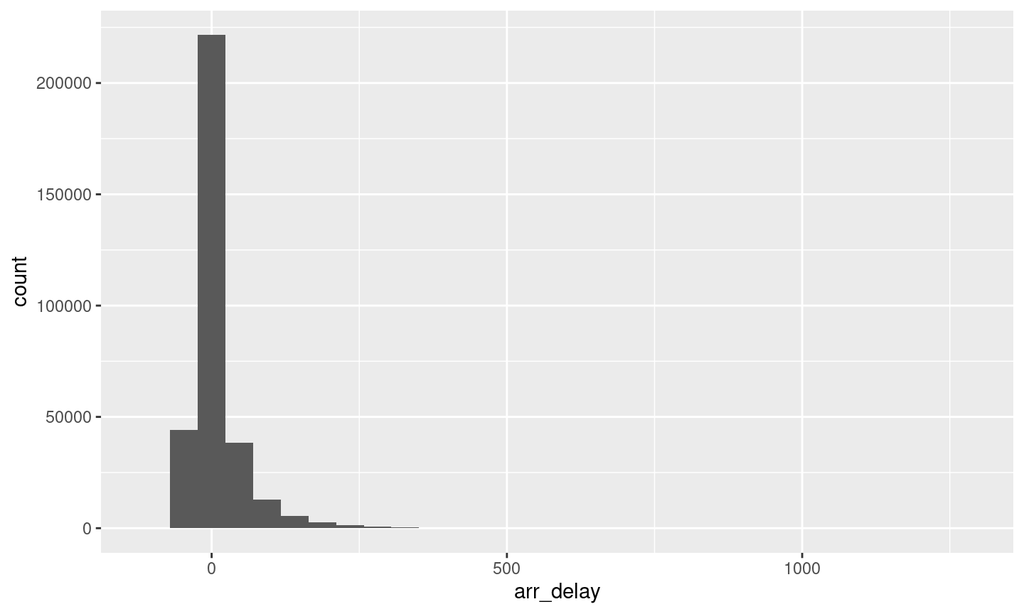

## Vizualization

### Prettier Histogram of Arrival Delays

```r
ggplot(flights, aes(x = arr_delay)) +
  geom_histogram(fill = "magenta", alpha = .7, colour = "black") +
  theme_bw()
```

## Vizualization

### Prettier Histogram of Arrival Delays

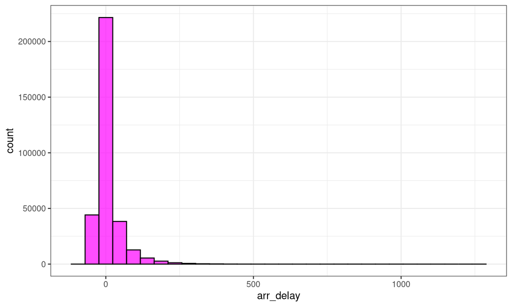

## Vizualization

### Prettier Histogram of Arrival Delays by Carrier

```r
ggplot(flights, aes(x = arr_delay)) +
  facet_wrap(~ carrier) +
  geom_histogram(fill = "magenta", alpha = .7, colour = "black") +
  theme_bw()
```

## Vizualization

### Prettier Histogram of Arrival Delays by Carrier

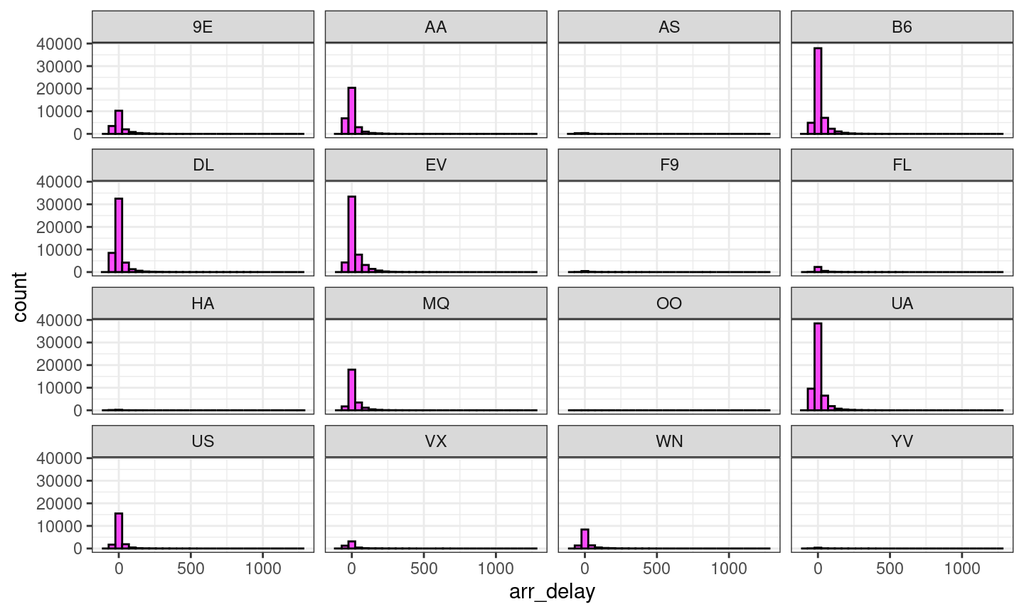

## Vizualization

### Total # of Delays by Date and Carrier

```r
total_delays <- flights %>%
  group_by(month, day, carrier) %>%
  summarise(Num_Delays = sum(arr_delay > 0 | dep_delay > 0, na.rm = T)) %>%
  left_join(airlines, by = "carrier") %>%
  group_by(carrier) %>%
  arrange(month, day) %>%
  mutate(day_of_year = 1:n()) %>%
  ungroup()
```

## Vizualization

### Total # of Delays by Date and Carrier

```r
glimpse(total_delays)
```

```
## Rows: 5,432
## Columns: 6
## $ month       <int> 1, 1, 1, 1, 1, 1, 1, 1, 1, 1, 1, 1, 1, 1, 1, 1, 1, 1, 1, …
## $ day         <int> 1, 1, 1, 1, 1, 1, 1, 1, 1, 1, 1, 1, 1, 1, 2, 2, 2, 2, 2, …
## $ carrier     <chr> "9E", "AA", "AS", "B6", "DL", "EV", "F9", "FL", "HA", "MQ…
## $ Num_Delays  <int> 15, 60, 0, 105, 35, 85, 1, 8, 0, 58, 128, 15, 6, 23, 38, …
## $ name        <chr> "Endeavor Air Inc.", "American Airlines Inc.", "Alaska Ai…
## $ day_of_year <int> 1, 1, 1, 1, 1, 1, 1, 1, 1, 1, 1, 1, 1, 1, 2, 2, 2, 2, 2, …
```

## Vizualization

### Total # of Delays by Date and Carrier

```r
ggplot(total_delays, aes(x = Num_Delays)) +
  facet_wrap(~ carrier) +
  geom_histogram(alpha = .7, fill = "dodgerblue") +
  theme_dark() +
  labs(y = "Frequency", x = "# of Daily Delays")
```

## Vizualization

### Total # of Delays by Date and Carrier

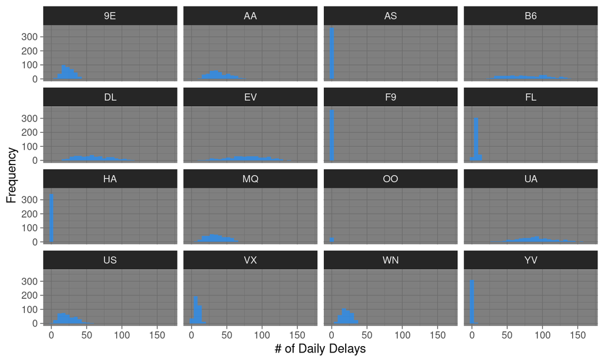

## Vizualization

### Total # of Delays by Date and Carrier

```r
ggplot(total_delays, aes(x = day_of_year, y = Num_Delays,
                         colour = carrier)) +
  geom_line() +
  theme_bw() +
  labs(y = "# of Delays", x = "Day of Year")
```

## Vizualization

### Total # of Delays by Date and Carrier

[figure not shown]

## Conclusion

- Data pipelines with **dplyr** makes life a lot easier.
- Code readiblity and flexibility is important
- This pipeline makes playing with **ggplot2** a breeze.

GitHub: https://github.com/BruceBugbee/rmacc-R-talk